# PM 566 Homework 2

Author

Uma Agarwal

```r
library(tidyverse)
library(nycflights13)
library(RColorBrewer)

airlines <- airlines
airports <- airports
flights <- flights
planes <- planes
weather <- weather

dim(flights)
```

```
[1] 336776     19
```

```r
head(flights)
```

```
# A tibble: 6 × 19
   year month   day dep_time sched_dep_time dep_delay arr_time sched_arr_time
  <int> <int> <int>    <int>          <int>     <dbl>    <int>          <int>
1  2013     1     1      517            515         2      830            819
2  2013     1     1      533            529         4      850            830
3  2013     1     1      542            540         2      923            850
4  2013     1     1      544            545        -1     1004           1022
5  2013     1     1      554            600        -6      812            837
6  2013     1     1      554            558        -4      740            728
# ℹ 11 more variables: arr_delay <dbl>, carrier <chr>, flight <int>,
#   tailnum <chr>, origin <chr>, dest <chr>, air_time <dbl>, distance <dbl>,
#   hour <dbl>, minute <dbl>, time_hour <dttm>
```

```r
tail(flights)
```

```
# A tibble: 6 × 19
   year month   day dep_time sched_dep_time dep_delay arr_time sched_arr_time
  <int> <int> <int>    <int>          <int>     <dbl>    <int>          <int>
1  2013     9    30       NA           1842        NA       NA           2019
2  2013     9    30       NA           1455        NA       NA           1634
3  2013     9    30       NA           2200        NA       NA           2312
4  2013     9    30       NA           1210        NA       NA           1330
5  2013     9    30       NA           1159        NA       NA           1344
6  2013     9    30       NA            840        NA       NA           1020
# ℹ 11 more variables: arr_delay <dbl>, carrier <chr>, flight <int>,
#   tailnum <chr>, origin <chr>, dest <chr>, air_time <dbl>, distance <dbl>,
#   hour <dbl>, minute <dbl>, time_hour <dttm>
```

```r
names(flights)
```

```
 [1] "year"           "month"          "day"            "dep_time"
 [5] "sched_dep_time" "dep_delay"      "arr_time"       "sched_arr_time"
 [9] "arr_delay"      "carrier"        "flight"         "tailnum"
[13] "origin"         "dest"           "air_time"       "distance"
[17] "hour"           "minute"         "time_hour"
```

```r
summary(flights)
```

```
      year          month             day           dep_time    sched_dep_time
 Min.   :2013   Min.   : 1.000   Min.   : 1.00   Min.   :   1   Min.   : 106
 1st Qu.:2013   1st Qu.: 4.000   1st Qu.: 8.00   1st Qu.: 907   1st Qu.: 906
 Median :2013   Median : 7.000   Median :16.00   Median :1401   Median :1359
 Mean   :2013   Mean   : 6.549   Mean   :15.71   Mean   :1349   Mean   :1344
 3rd Qu.:2013   3rd Qu.:10.000   3rd Qu.:23.00   3rd Qu.:1744   3rd Qu.:1729
 Max.   :2013   Max.   :12.000   Max.   :31.00   Max.   :2400   Max.   :2359
                                                 NA's   :8255
   dep_delay          arr_time    sched_arr_time   arr_delay
 Min.   : -43.00   Min.   :   1   Min.   :   1   Min.   : -86.000
 1st Qu.:  -5.00   1st Qu.:1104   1st Qu.:1124   1st Qu.: -17.000
 Median :  -2.00   Median :1535   Median :1556   Median :  -5.000
 Mean   :  12.64   Mean   :1502   Mean   :1536   Mean   :   6.895
 3rd Qu.:  11.00   3rd Qu.:1940   3rd Qu.:1945   3rd Qu.:  14.000
 Max.   :1301.00   Max.   :2400   Max.   :2359   Max.   :1272.000
 NA's   :8255      NA's   :8713                  NA's   :9430
   carrier              flight       tailnum             origin
 Length:336776      Min.   :   1   Length:336776      Length:336776
 Class :character   1st Qu.: 553   Class :character   Class :character
 Mode  :character   Median :1496   Mode  :character   Mode  :character
                    Mean   :1972
                    3rd Qu.:3465
                    Max.   :8500

     dest              air_time        distance         hour
 Length:336776      Min.   : 20.0   Min.   :  17   Min.   : 1.00
 Class :character   1st Qu.: 82.0   1st Qu.: 502   1st Qu.: 9.00
 Mode  :character   Median :129.0   Median : 872   Median :13.00
                    Mean   :150.7   Mean   :1040   Mean   :13.18
                    3rd Qu.:192.0   3rd Qu.:1389   3rd Qu.:17.00
                    Max.   :695.0   Max.   :4983   Max.   :23.00
                    NA's   :9430
     minute        time_hour
 Min.   : 0.00   Min.   :2013-01-01 05:00:00
 1st Qu.: 8.00   1st Qu.:2013-04-04 13:00:00
 Median :29.00   Median :2013-07-03 10:00:00
 Mean   :26.23   Mean   :2013-07-03 05:22:54
 3rd Qu.:44.00   3rd Qu.:2013-10-01 07:00:00
 Max.   :59.00   Max.   :2013-12-31 23:00:00
```

**#1**

The most popular destination was to Chicago ORD, followed by Atlanta ATL and Los Angeles LAX. Over 17000 flights went to ORD, and just under 10000 flights went to DCA, the 10th most popular destination.

```r
flights %>%
  count(dest, sort = T) %>%
  top_n(10, n)
```

```
# A tibble: 10 × 2
   dest      n
   <chr> <int>
 1 ORD   17283
 2 ATL   17215
 3 LAX   16174
 4 BOS   15508
 5 MCO   14082
 6 CLT   14064
 7 SFO   13331
 8 FLL   12055
 9 MIA   11728
10 DCA    9705
```

**#2**

From this, we see that 3.24% of the flights are redeye flights.

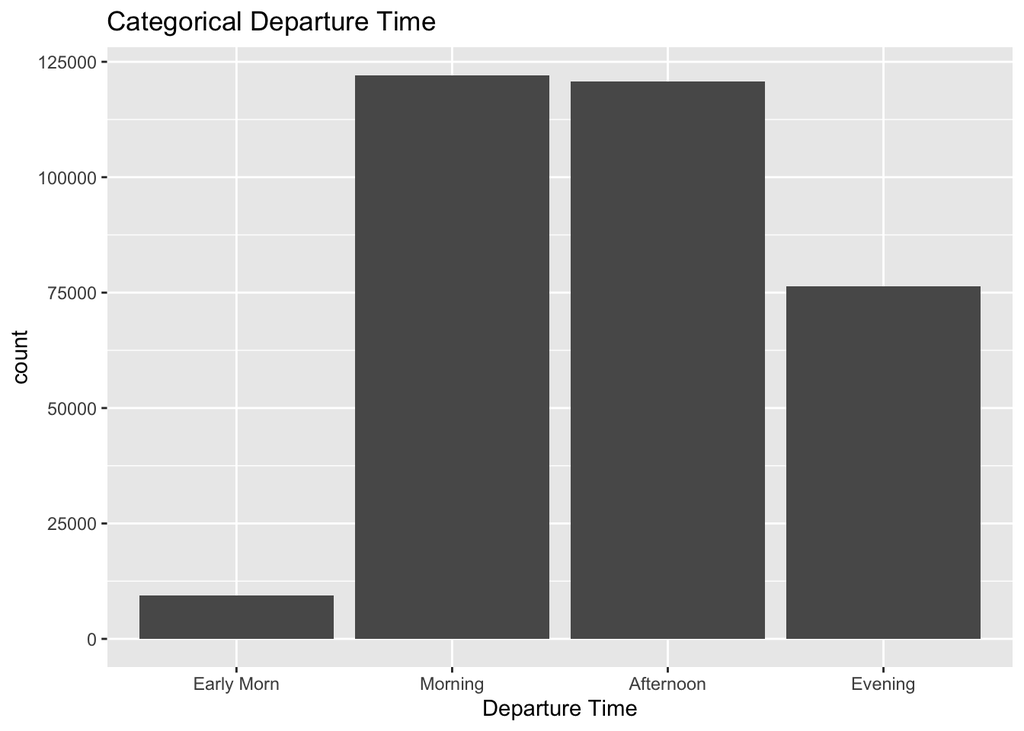

```r
flights <- flights %>%
  mutate(dep_time_cat = cut(dep_time,
                            breaks = c(0, 600, 1200, 1800, 2400),
                            labels = c("Early Morn", "Morning",
                                       "Afternoon", "Evening")))
flights %>%
  filter(!is.na(dep_time_cat)) %>%
  ggplot(aes(x = dep_time_cat)) +
  geom_bar() +
  labs(x = "Departure Time", title = "Categorical Departure Time")
```

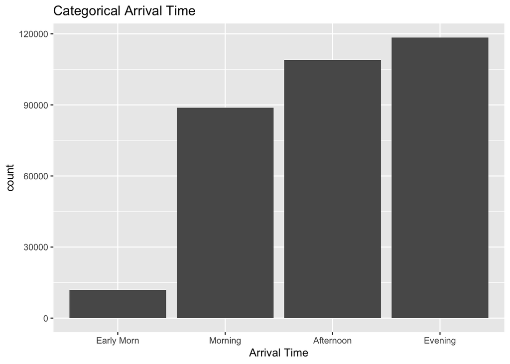

```r
flights <- flights %>%
  mutate(arr_time_cat = cut(arr_time,
                            breaks = c(0, 600, 1200, 1800, 2400),
                            labels = c("Early Morn", "Morning",
                                       "Afternoon", "Evening")))
flights %>%
  filter(!is.na(arr_time_cat)) %>%
  ggplot(aes(x = arr_time_cat)) +
  geom_bar() +
  labs(x = "Arrival Time", title = "Categorical Arrival Time")
```

```r
flights <- flights %>%
  mutate(redeye = ifelse((dep_time_cat == "Afternoon" | dep_time_cat == "Evening") &
                          (arr_time_cat == "Early Morn" | arr_time_cat == "Morning"),
                         TRUE, FALSE))
flights %>%
  summarize(prop_redeye = mean(redeye, na.rm = T))
```

```
# A tibble: 1 × 1
  prop_redeye
        <dbl>
1      0.0324
```

**#3**

Yes, 17 planes flew for multiple airlines. Only 4 airlines were included among these: 9E (Endeavor Air), DL (Delta), EV (Express Jet), and FL (AirTran).

```r
multi_airlines <- flights %>%
  filter(!is.na(tailnum)) %>%
  group_by(tailnum) %>%
  filter(n_distinct(carrier) > 1)

unique(multi_airlines$tailnum)
```

```
 [1] "N978AT" "N977AT" "N935AT" "N232PQ" "N933AT" "N990AT" "N146PQ" "N153PQ"
 [9] "N981AT" "N979AT" "N181PQ" "N989AT" "N176PQ" "N228PQ" "N994AT" "N200PQ"
[17] "N197PQ"
```

```r
multi_airlines %>% count(carrier)
```

```
# A tibble: 34 × 3
# Groups:   tailnum [17]
   tailnum carrier     n
   <chr>   <chr>   <int>
 1 N146PQ  9E          8
 2 N146PQ  EV         36
 3 N153PQ  9E          5
 4 N153PQ  EV         26
 5 N176PQ  9E          7
 6 N176PQ  EV         21
 7 N181PQ  9E          4
 8 N181PQ  EV         35
 9 N197PQ  9E          2
10 N197PQ  EV         31
# ℹ 24 more rows
```

```r
table(multi_airlines$carrier)
```

```
 9E  DL  EV  FL
 48 376 232 168
```

**#4**

The diagram does not directly show that the weather and airports datasets are related via airports$faa and weather$origin. The diagram shows the relationship between these through the flights dataset as an intermediate step, but ideally there should be an arrow directly between these two categories to display this relationship accurately.

```r
names(airports)
```

```
[1] "faa"   "name"  "lat"   "lon"   "alt"   "tz"    "dst"   "tzone"
```

```r
names(weather)
```

```
 [1] "origin"     "year"       "month"      "day"        "hour"
 [6] "temp"       "dewp"       "humid"      "wind_dir"   "wind_speed"
[11] "wind_gust"  "precip"     "pressure"   "visib"      "time_hour"
```

**#5**

Pasting together these 5 variables creates a unique combination for all but 3 of the total observations. The reason these ones are duplicated is because all of these occurred at 1am on November 3, which is the date and time that DST ended. Therefore, 1am occurred 2x as the clocks switched times.

```r
weather <- weather %>%
  mutate(all_info = paste(year, month, day, hour, origin, sep = " "))

weather %>%
  count(duplicated(all_info))
```

```
# A tibble: 2 × 2
  `duplicated(all_info)`     n
  <lgl>                  <int>
1 FALSE                  26112
2 TRUE                       3
```

```r
weather %>%
  filter(duplicated(all_info))
```

```
# A tibble: 3 × 16
  origin  year month   day  hour  temp  dewp humid wind_dir wind_speed wind_gust
  <chr>  <int> <int> <int> <int> <dbl> <dbl> <dbl>    <dbl>      <dbl>     <dbl>
1 EWR     2013    11     3     1  50    39.0  65.8      290       5.75        NA
2 JFK     2013    11     3     1  52.0  37.9  58.6      310       6.90        NA
3 LGA     2013    11     3     1  54.0  39.9  58.9      310       8.06        NA
# ℹ 5 more variables: precip <dbl>, pressure <dbl>, visib <dbl>,
#   time_hour <dttm>, all_info <chr>
```

**#6**

The dep_delay variable is right-skewed; there appears to be an outlier(s) somewhere around 1300. The arr_delay variable has a very similar distribution with similar outlier(s). Temperature and wind speed seem to have a normal(ish) distribution. Wind gust, precipitation, and visibility are all skewed.

There doesn’t seem to be any implausible data or values that seem like placeholders for NAs. There are many NAs in the continuous variables.

```r
# merge flights and weather by origin and time_hour
flight_weather <- merge(flights, weather, by = c("origin", "time_hour", "year", "month", "day"))
```

```r
dim(flight_weather)
```

```
[1] 335220     33
```

```r
names(flight_weather)
```

```
 [1] "origin"         "time_hour"      "year"           "month"
 [5] "day"            "dep_time"       "sched_dep_time" "dep_delay"
 [9] "arr_time"       "sched_arr_time" "arr_delay"      "carrier"
[13] "flight"         "tailnum"        "dest"           "air_time"
[17] "distance"       "hour.x"         "minute"         "dep_time_cat"
[21] "arr_time_cat"   "redeye"         "hour.y"         "temp"
[25] "dewp"           "humid"          "wind_dir"       "wind_speed"
[29] "wind_gust"      "precip"         "pressure"       "visib"
[33] "all_info"
```

```r
str(flight_weather)
```

```
'data.frame':   335220 obs. of  33 variables:
 $ origin        : chr  "EWR" "EWR" "EWR" "EWR" ...
 $ time_hour     : POSIXct, format: "2013-01-01 05:00:00" "2013-01-01 05:00:00" ...
 $ year          : int  2013 2013 2013 2013 2013 2013 2013 2013 2013 2013 ...
 $ month         : int  1 1 1 1 1 1 1 1 1 1 ...
 $ day           : int  1 1 1 1 1 1 1 1 1 1 ...
 $ dep_time      : int  517 554 732 629 624 643 644 643 601 559 ...
 $ sched_dep_time: int  515 558 645 630 630 646 636 645 600 600 ...
 $ dep_delay     : num  2 -4 47 -1 -6 -3 8 -2 1 -1 ...
 $ arr_time      : int  830 740 1011 824 909 922 931 837 844 854 ...
 $ sched_arr_time: int  819 728 941 833 840 940 940 848 850 902 ...
 $ arr_delay     : num  11 12 30 -9 29 -18 -9 -11 -6 -8 ...
 $ carrier       : chr  "UA" "UA" "UA" "US" ...
 $ flight        : int  1545 1696 1111 1019 4626 556 1701 926 343 1187 ...
 $ tailnum       : chr  "N14228" "N39463" "N37456" "N426US" ...
```

[output cut: 19 more lines]

```r
head(flight_weather)
```

```
  origin           time_hour year month day dep_time sched_dep_time dep_delay
1    EWR 2013-01-01 05:00:00 2013     1   1      517            515         2
2    EWR 2013-01-01 05:00:00 2013     1   1      554            558        -4
3    EWR 2013-01-01 06:00:00 2013     1   1      732            645        47
4    EWR 2013-01-01 06:00:00 2013     1   1      629            630        -1
5    EWR 2013-01-01 06:00:00 2013     1   1      624            630        -6
6    EWR 2013-01-01 06:00:00 2013     1   1      643            646        -3
  arr_time sched_arr_time arr_delay carrier flight tailnum dest air_time
1      830            819        11      UA   1545  N14228  IAH      227
2      740            728        12      UA   1696  N39463  ORD      150
3     1011            941        30      UA   1111  N37456  MCO      145
4      824            833        -9      US   1019  N426US  CLT       91
5      909            840        29      EV   4626  N11107  MSP      190
6      922            940       -18      UA    556  N497UA  PBI      146
  distance hour.x minute dep_time_cat arr_time_cat redeye hour.y  temp  dewp
1     1400      5     15   Early Morn      Morning  FALSE      5 39.02 28.04
2      719      5     58   Early Morn      Morning  FALSE      5 39.02 28.04
3      937      6     45      Morning      Morning  FALSE      6 37.94 28.04
4      529      6     30      Morning      Morning  FALSE      6 37.94 28.04
5     1008      6     30      Morning      Morning  FALSE      6 37.94 28.04
6     1023      6     46      Morning      Morning  FALSE      6 37.94 28.04
  humid wind_dir wind_speed wind_gust precip pressure visib       all_info
1 64.43      260   12.65858        NA      0   1011.9    10 2013 1 1 5 EWR
2 64.43      260   12.65858        NA      0   1011.9    10 2013 1 1 5 EWR
3 67.21      240   11.50780        NA      0   1012.4    10 2013 1 1 6 EWR
4 67.21      240   11.50780        NA      0   1012.4    10 2013 1 1 6 EWR
5 67.21      240   11.50780        NA      0   1012.4    10 2013 1 1 6 EWR
6 67.21      240   11.50780        NA      0   1012.4    10 2013 1 1 6 EWR
```

```r
tail(flight_weather)
```

```
       origin           time_hour year month day dep_time sched_dep_time
335215    LGA 2013-12-30 18:00:00 2013    12  30     1828           1816
335216    LGA 2013-12-30 18:00:00 2013    12  30     1825           1835
335217    LGA 2013-12-30 18:00:00 2013    12  30     1758           1800
335218    LGA 2013-12-30 18:00:00 2013    12  30     1844           1855
335219    LGA 2013-12-30 18:00:00 2013    12  30     1902           1850
335220    LGA 2013-12-30 18:00:00 2013    12  30     1840           1845
       dep_delay arr_time sched_arr_time arr_delay carrier flight tailnum dest
335215        12     2032           2035        -3      DL   2019  N975DL  MSP
335216       -10     2013           2020        -7      AA    359  N3HPAA  ORD
335217        -2     2032           2046       -14      DL     61  N929DL  ATL
335218       -11     2222           2220         2      DL   2139  N965DL  MIA
335219        12     2046           2030        16      MQ   3674  N534MQ  CLE
335220        -5     2036           2054       -18      DL   2458  N941DL  DTW
       air_time distance hour.x minute dep_time_cat arr_time_cat redeye hour.y
```

[output cut: 20 more lines]

```r
summary(flight_weather)
```

```
    origin            time_hour                        year
 Length:335220      Min.   :2013-01-01 05:00:00   Min.   :2013
 Class :character   1st Qu.:2013-04-04 08:00:00   1st Qu.:2013
 Mode  :character   Median :2013-07-02 16:00:00   Median :2013
                    Mean   :2013-07-02 15:20:49   Mean   :2013
                    3rd Qu.:2013-09-30 09:00:00   3rd Qu.:2013
                    Max.   :2013-12-30 18:00:00   Max.   :2013

     month             day           dep_time    sched_dep_time
 Min.   : 1.000   Min.   : 1.00   Min.   :   1   Min.   : 106
 1st Qu.: 4.000   1st Qu.: 8.00   1st Qu.: 907   1st Qu.: 906
 Median : 7.000   Median :16.00   Median :1400   Median :1359
 Mean   : 6.531   Mean   :15.67   Mean   :1348   Mean   :1344
 3rd Qu.: 9.000   3rd Qu.:23.00   3rd Qu.:1743   3rd Qu.:1729
 Max.   :12.000   Max.   :31.00   Max.   :2400   Max.   :2359
                                  NA's   :8227
   dep_delay          arr_time    sched_arr_time   arr_delay
 Min.   : -43.00   Min.   :   1   Min.   :   1   Min.   : -86.000
 1st Qu.:  -5.00   1st Qu.:1105   1st Qu.:1124   1st Qu.: -17.000
 Median :  -2.00   Median :1535   Median :1556   Median :  -5.000
 Mean   :  12.64   Mean   :1502   Mean   :1536   Mean   :   6.883
 3rd Qu.:  11.00   3rd Qu.:1940   3rd Qu.:1945   3rd Qu.:  14.000
 Max.   :1301.00   Max.   :2400   Max.   :2359   Max.   :1272.000
 NA's   :8227      NA's   :8685                  NA's   :9401
   carrier              flight       tailnum              dest
 Length:335220      Min.   :   1   Length:335220      Length:335220
 Class :character   1st Qu.: 554   Class :character   Class :character
 Mode  :character   Median :1496   Mode  :character   Mode  :character
                    Mean   :1972
                    3rd Qu.:3466
                    Max.   :8500

    air_time        distance        hour.x          minute
 Min.   : 20.0   Min.   :  17   Min.   : 1.00   Min.   : 0.00
 1st Qu.: 82.0   1st Qu.: 502   1st Qu.: 9.00   1st Qu.: 8.00
 Median :129.0   Median : 872   Median :13.00   Median :29.00
 Mean   :150.6   Mean   :1040   Mean   :13.17   Mean   :26.23
 3rd Qu.:191.0   3rd Qu.:1389   3rd Qu.:17.00   3rd Qu.:44.00
 Max.   :695.0   Max.   :4983   Max.   :23.00   Max.   :59.00
 NA's   :9401
```

[output cut: 16 more lines]

```
   wind_speed       wind_gust          precip            pressure
 Min.   : 0.000   Min.   :16.11    Min.   :0.000000   Min.   : 983.8
 1st Qu.: 6.905   1st Qu.:20.71    1st Qu.:0.000000   1st Qu.:1012.7
 Median :10.357   Median :24.17    Median :0.000000   Median :1017.5
 Mean   :11.114   Mean   :25.25    Mean   :0.004564   Mean   :1017.8
 3rd Qu.:14.960   3rd Qu.:28.77    3rd Qu.:0.000000   3rd Qu.:1022.8
 Max.   :42.579   Max.   :66.75    Max.   :1.210000   Max.   :1042.1
 NA's   :78       NA's   :254835                      NA's   :37232
     visib          all_info
 Min.   : 0.000   Length:335220
 1st Qu.:10.000   Class :character
 Median :10.000   Mode  :character
 Mean   : 9.256
 3rd Qu.:10.000
 Max.   :10.000
```

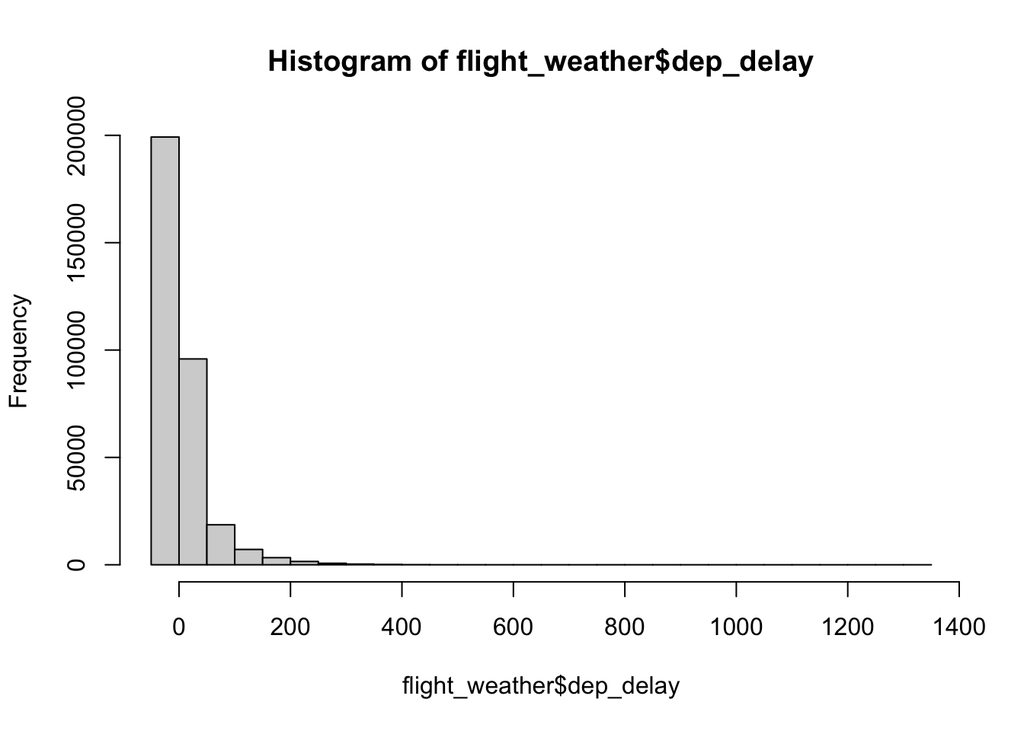

```r
hist(flight_weather$dep_delay)
```

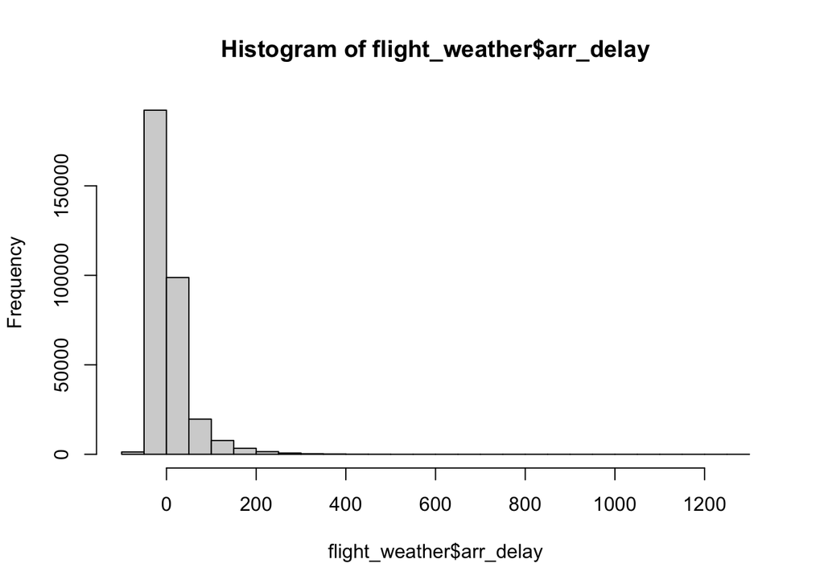

```r
hist(flight_weather$arr_delay)
```

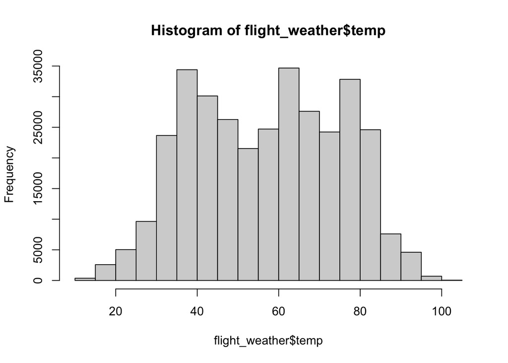

```r
hist(flight_weather$temp)
```

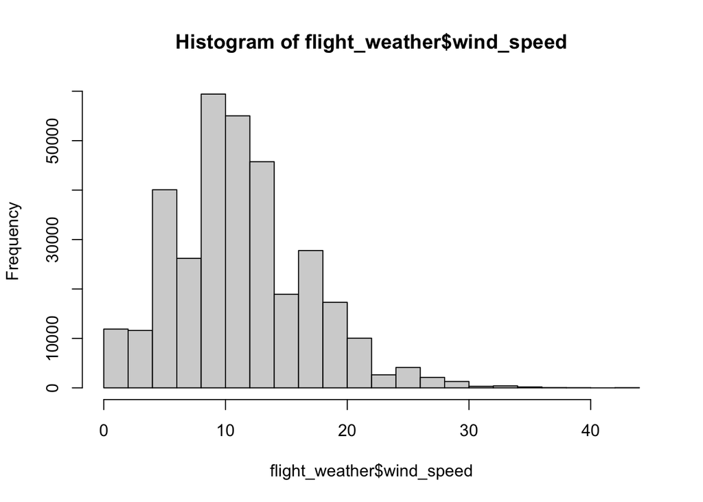

```r
hist(flight_weather$wind_speed)
```

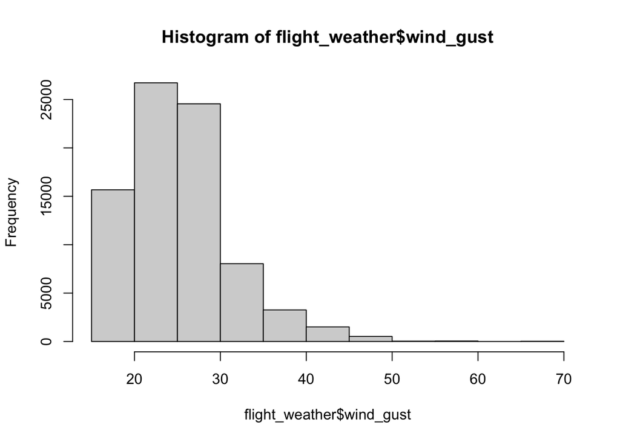

```r
hist(flight_weather$wind_gust)
```

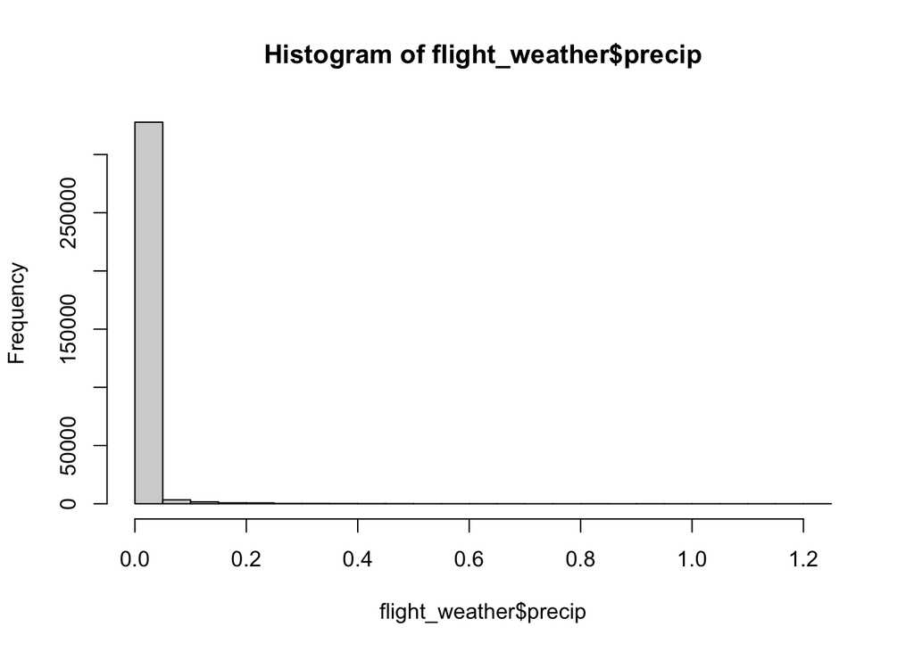

```r
hist(flight_weather$precip)
```

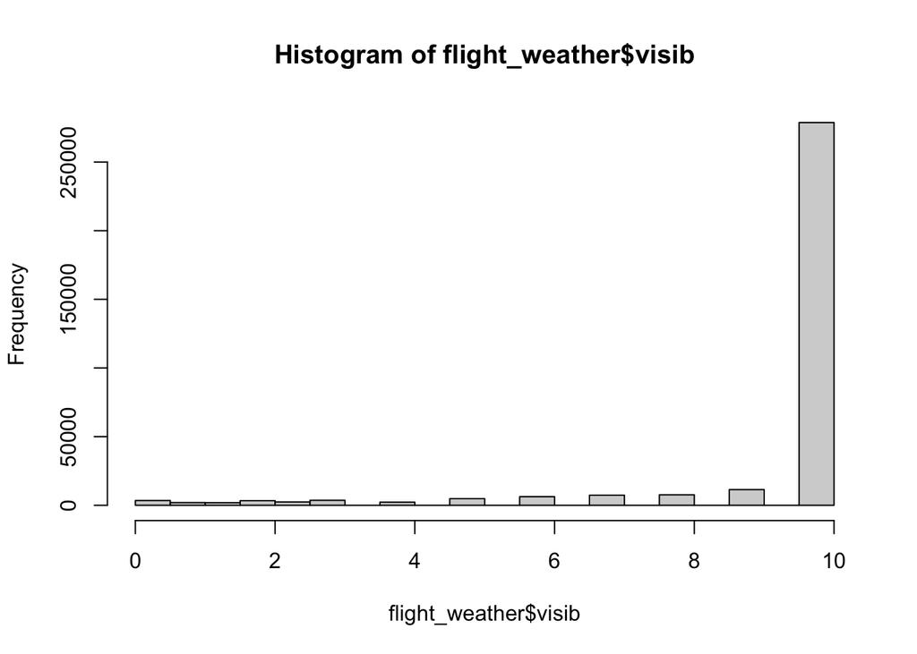

```r
hist(flight_weather$visib)
```

**#7**

The day with the highest average departure delay was March 8, with an average delay of 83.54 min. LGA had the worst single day for delays, which was also March 8. LGA had the single worst hour for delays, which was July 28 at 21:00.

```r
# avg dep_delay by day
delay_by_day <- flight_weather %>%
  group_by(month, day) %>%
  summarise(dep_delay_avg = mean(dep_delay, na.rm = T))
delay_by_day %>%
  arrange(desc(dep_delay_avg)) %>%
  head()
```

```
# A tibble: 6 × 3
# Groups:   month [5]
  month   day dep_delay_avg
  <int> <int>         <dbl>
1     3     8          83.5
2     7     1          56.2
3     7    10          52.9
4    12     5          52.3
5     9     2          51.6
6     5    23          51.1
```

```r
# avg dep_delay by day and origin
delay_origin_day <- flight_weather %>%
  group_by(origin, month, day) %>%
  summarise(avgdelay_ori_day = mean(dep_delay, na.rm = T))
delay_origin_day %>%
  arrange(desc(avgdelay_ori_day)) %>%
  head()
```

```
# A tibble: 6 × 4
# Groups:   origin, month [6]
  origin month   day avgdelay_ori_day
  <chr>  <int> <int>            <dbl>
1 LGA        3     8            106.
2 EWR        3     8             97.8
3 LGA        9     2             80.5
4 LGA       12     5             75.2
5 JFK        7    10             63.6
6 LGA        7     1             62.4
```

```r
# avg dep_delay by origin and hour
delay_origin_hour <- flight_weather %>%
  group_by(origin, time_hour) %>%
  summarise(avgdelay_hour = mean(dep_delay, na.rm = T))
delay_origin_hour %>%
  arrange(desc(avgdelay_hour)) %>%
  head()
```

```
# A tibble: 6 × 3
# Groups:   origin [2]
  origin time_hour           avgdelay_hour
  <chr>  <dttm>                      <dbl>
1 LGA    2013-07-28 21:00:00          280.
2 EWR    2013-02-09 10:00:00          269
3 EWR    2013-02-09 09:00:00          266
4 LGA    2013-09-02 16:00:00          250.
5 LGA    2013-07-22 18:00:00          246.
6 LGA    2013-07-28 19:00:00          240.
```

**#8**

The highest average delays seem to be for destinations in the eastern US, especially in the “Tornado Alley” region.

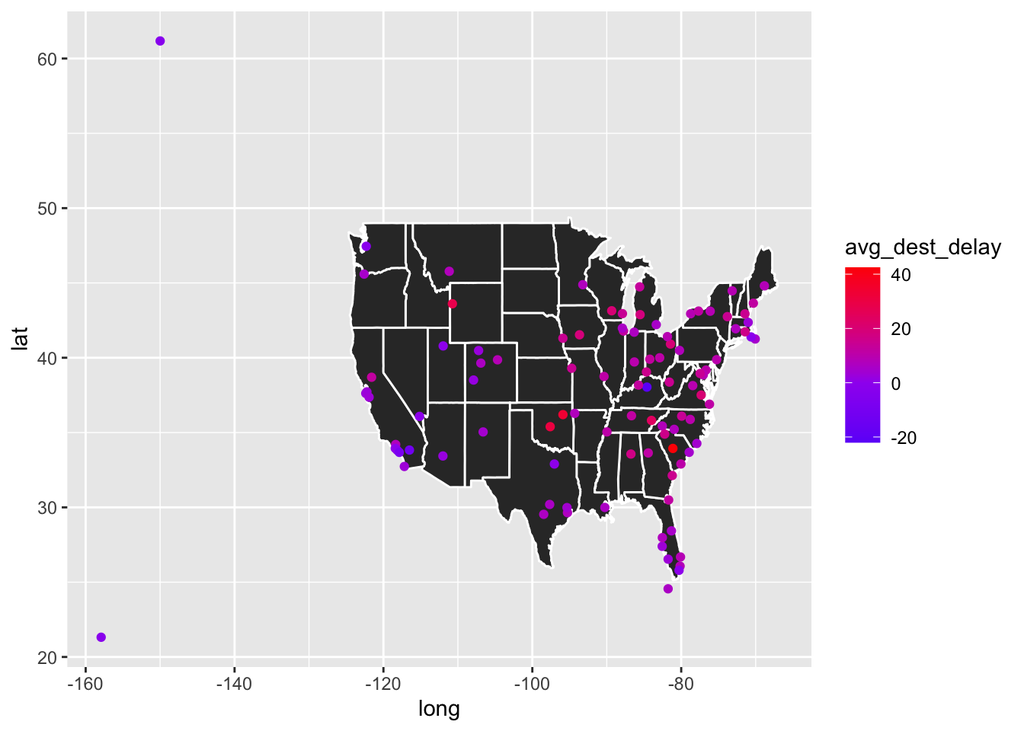

```r
# avg arr_delay by destination
delay_by_dest <- flight_weather %>%
  group_by(dest) %>%
  summarise(avg_dest_delay = mean(arr_delay, na.rm = T))

airports <- left_join(airports, delay_by_dest,
                      by = join_by(faa == dest))

us_map <- map_data("state")
ggplot() +
  geom_polygon(data = us_map, aes(x = long, y = lat, group = group),
               color = "white") +
  geom_point(data = airports %>% filter(!is.na(avg_dest_delay)),
             mapping = aes(x = lon, y = lat, color = avg_dest_delay)) +
  scale_color_gradient2(low = "blue", high = "red", mid = "purple")
```

**#9**

First, I created a categorical variable for precipitation: TRUE if there was any rain/snow, FALSE if it was dry. I found that 6.86% of the flights were recorded to have some precipitation at the time of departure, and it looks like the average delay was higher for the “not dry” group. However, when I plotted these with boxplots, I found that the highest delays weren’t part of the “not dry” group, and, to the naked eye, the difference in the means doesn’t look like a lot. Therefore, precipitation doesn’t seem to be the sole cause of the worst delays. I did a similar thing to see if wind gust affected delays; the means between those with any wind gust and those with none were very similar. Boxplots showed that the highest delays didn’t have any wind gust. Therefore, wind gust also doesn’t seem to be the cause of the worst delays. I repeated this one more time with a fog categorical variable. The average delay for the “fog” group did seem to be higher than that of the “clear” group, but overall it doesn’t look like fog was the cause of the worst delays either.

Even though rain, wind, and fog don’t seem to individually cause the worst delays, it is possible a combination of one or more of these weather conditions causes the worst delays. I decided to subset the data to focus on flights determined to be “not dry” and examined how delays were affected by wind speed and visibility within this group. It does appear, despite the relationship not being very strong, that **delays do increase when there is precipitation and high wind speeds. There may also be increased delays when there is precipitation and low visibility**, although this relationship looks less strong., likely because there are significantly fewer data points for those conditions.

```r
# make a categorical precipitation variable
flight_weather <- flight_weather %>%
  mutate(not_dry = ifelse(precip > 0, TRUE, FALSE))

flight_weather %>%
  summarise(rain.p = mean(not_dry))
```

```
      rain.p
1 0.06861762
```

```r
flight_weather %>%
  group_by(not_dry) %>%
  summarise(avg_delay = mean(dep_delay, na.rm = T))
```

```
# A tibble: 2 × 2
  not_dry avg_delay
  <lgl>       <dbl>
1 FALSE        11.4
2 TRUE         30.9
```

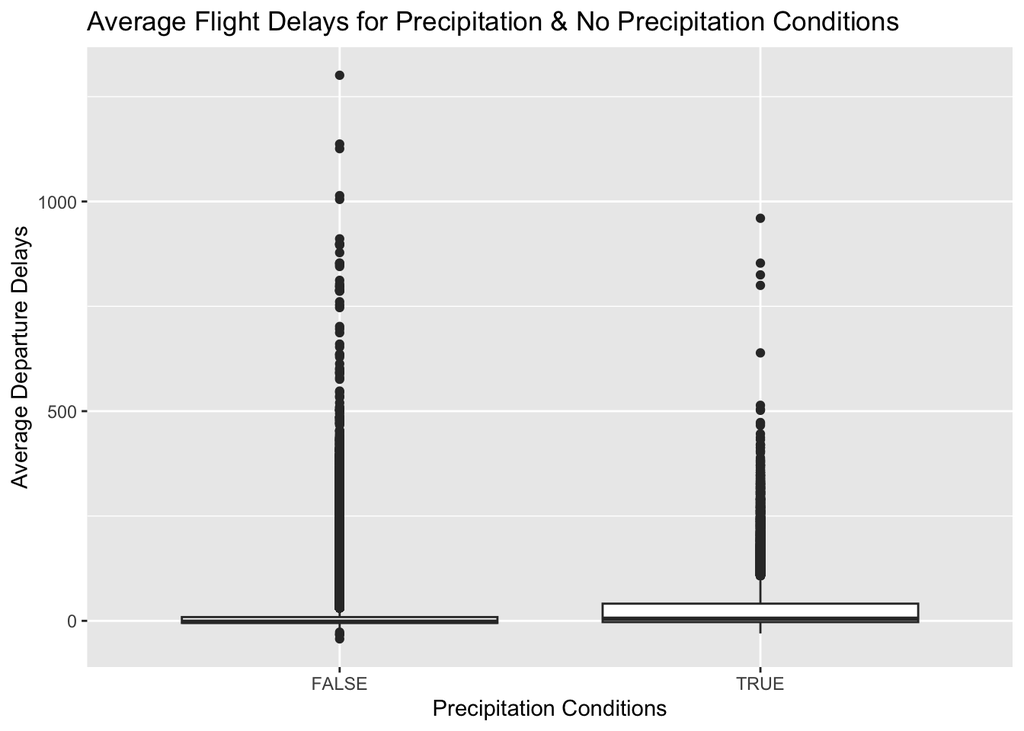

```r
flight_weather %>%
  ggplot(aes(x = not_dry, y = dep_delay)) +
  geom_boxplot() +
  labs(title = "Average Flight Delays for Precipitation & No Precipitation Conditions",
       x = "Precipitation Conditions",
       y = "Average Departure Delays")
```

```r
# wind_gust categorical
flight_weather %>%
  group_by(is.na(wind_gust)) %>%
  summarise(avg_delay = mean(dep_delay, na.rm = T))
```

```
# A tibble: 2 × 2
  `is.na(wind_gust)` avg_delay
  <lgl>                  <dbl>
1 FALSE                   13.7
2 TRUE                    12.3
```

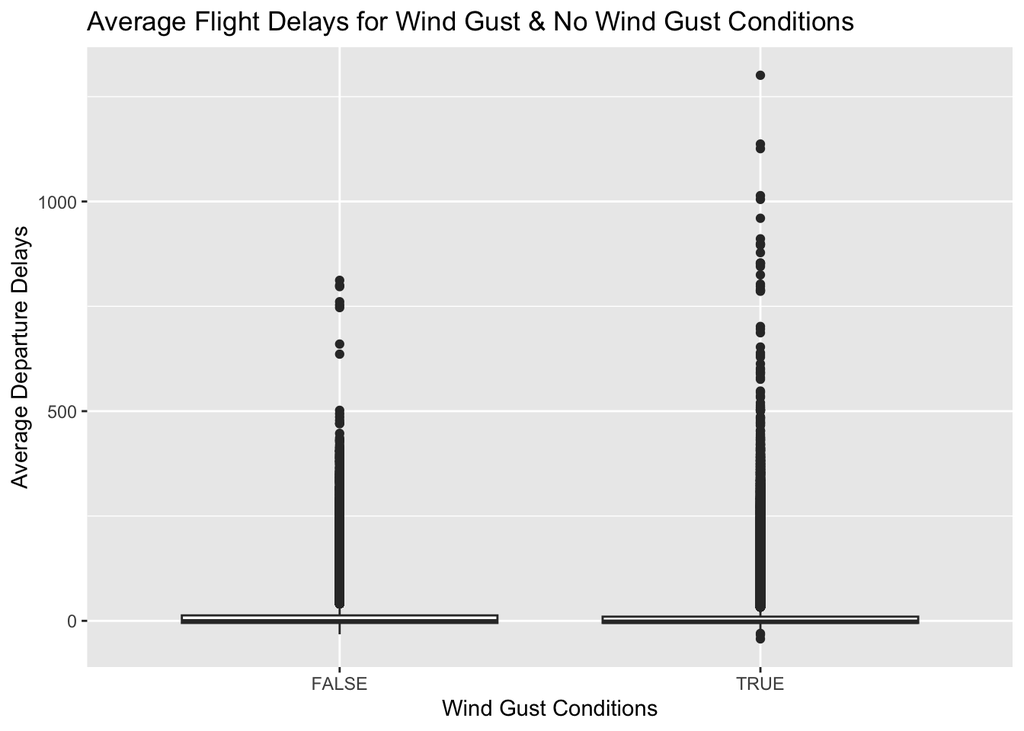

```r
flight_weather %>%
  ggplot(aes(x = is.na(wind_gust), y = dep_delay)) +
  geom_boxplot() +
  labs(title = "Average Flight Delays for Wind Gust & No Wind Gust Conditions",
       x = "Wind Gust Conditions",
       y = "Average Departure Delays")
```

```r
# fog categorical
flight_weather <- flight_weather %>%
  mutate(fog_cat = cut(visib,
                       breaks = c(0, 5, 9.9, 10),
                       labels = c("Fog", "Haze", "Clear")))

flight_weather %>%
  group_by(fog_cat) %>%
  summarise(avg_delay = mean(dep_delay, na.rm = T))
```

```
# A tibble: 4 × 2
  fog_cat avg_delay
  <fct>       <dbl>
1 Fog          24.0
2 Haze         19.3
3 Clear        11.0
4 <NA>         32.3
```

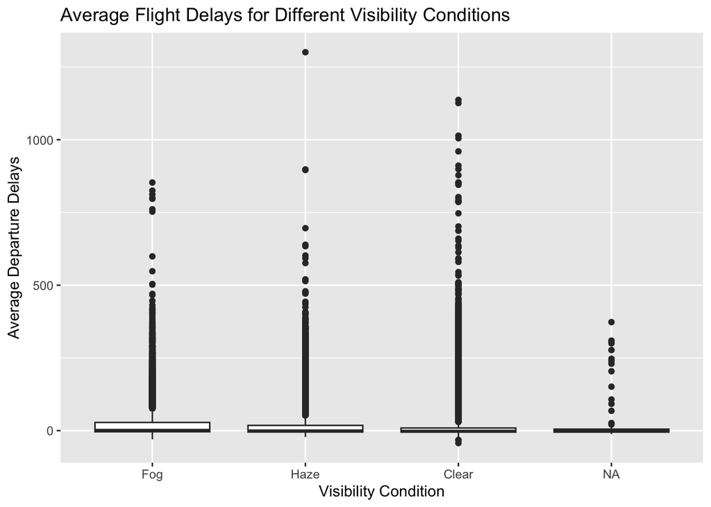

```r
flight_weather %>%
  ggplot(aes(x = fog_cat, y = dep_delay)) +
  geom_boxplot() +
  labs(title = "Average Flight Delays for Different Visibility Conditions",
       x = "Visibility Condition",
       y = "Average Departure Delays")
```

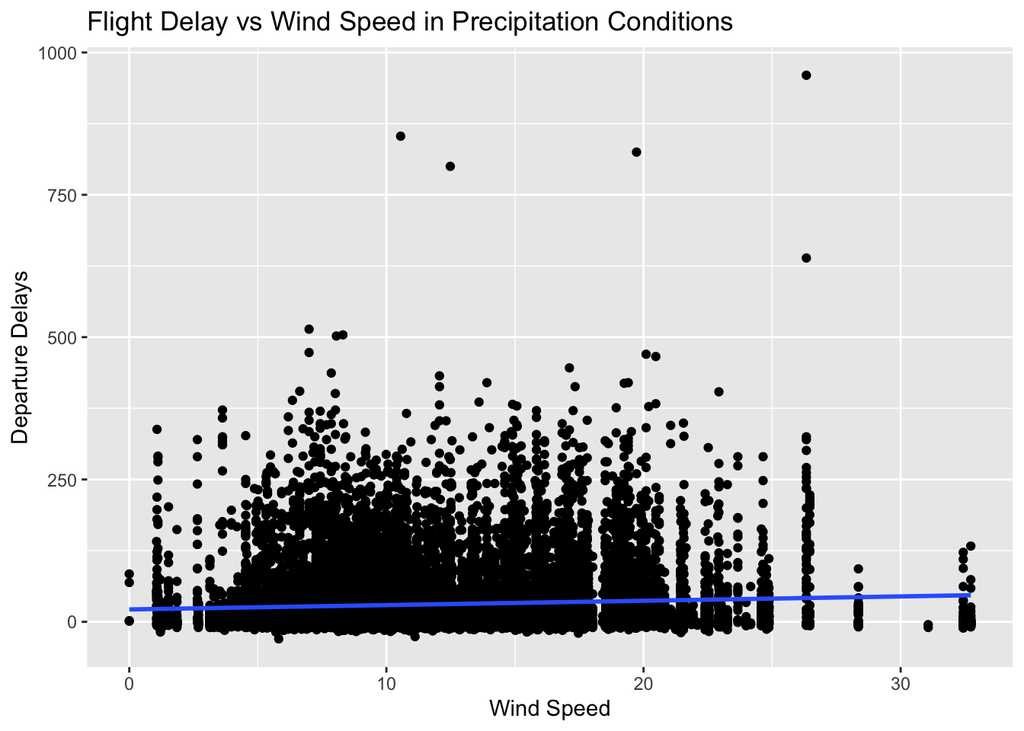

```r
# subset to examine wind in not_dry group
# first remove some of the wind_speed duplicates
avg_wind <- flight_weather %>%
  group_by(time_hour) %>%
  summarise(avg_windsp = mean(wind_speed, na.rm = TRUE))

flight_weather %>%
  filter(not_dry == TRUE) %>%
  left_join(avg_wind, by = "time_hour") %>%
  ggplot(aes(x = avg_windsp, y = dep_delay)) +
  geom_point() +
  geom_smooth(method = "lm") +
  labs(title = "Flight Delay vs Wind Speed in Precipitation Conditions",
       x = "Wind Speed",
       y = "Departure Delays")
```

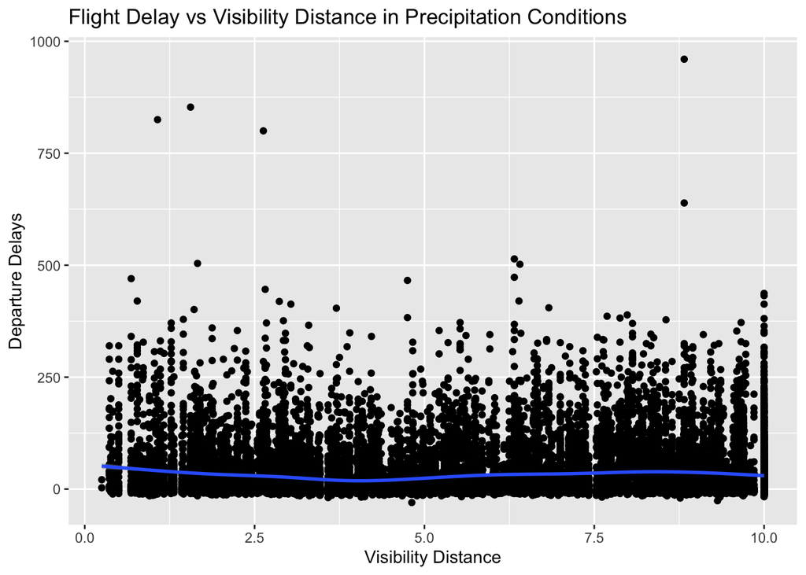

```r
# repeat with visib in not_dry group
avg_visib <- flight_weather %>%
  group_by(time_hour) %>%
  summarise(avg_visib = mean(visib, na.rm = TRUE))

flight_weather %>%
  filter(not_dry == TRUE) %>%
  left_join(avg_visib, by = "time_hour") %>%
  ggplot(aes(x = avg_visib, y = dep_delay)) +
  geom_point() +
  geom_smooth() +
  labs(title = "Flight Delay vs Visibility Distance in Precipitation Conditions",
       x = "Visibility Distance",
       y = "Departure Delays")
```